# Haunted Places

Author

Federico Alegría

> Halloween is coming soon, so we’re exploring a spooky dataset: a compilation of Haunted Places in the United States. The dataset was [compiled by Tim Renner](https://github.com/timothyrenner/shadowlands-haunted-places), using [The Shadowlands Haunted Places Index](https://www.theshadowlands.net/places/), and [shared on data.world](https://data.world/timothyrenner/haunted-places).

For Tidy Tuesday’s `2023_41`, the idea was to explore the spatial data stored in the `city_latitude` and `city_longitude` variables, and the textual data available across +10,000 reports on haunted places across the United States; stored the `description`[^1] strings.

```r
haunted_places <-
  readr::read_csv(
    'https://raw.githubusercontent.com/rfordatascience/tidytuesday/master/data/2023/2023-10-10/haunted_places.csv'
  )
```

**Required Packages**

```r
pacman::p_load(ggalt,
               ggdark,
               gt,
               gtExtras,
               leaflet,
               rcompanion,
               skimr,
               stringr,
               tidytext,
               tidyverse,
               wordcloud2)
```

## The Big Picture

**Clustered map for haunted places across the US**

```r
haunted_places |>
  filter(!is.na(city_latitude) | !is.na(city_longitude)) |>
  leaflet() |>
  addTiles() |>
  addProviderTiles("CartoDB.DarkMatter") |>
  addCircleMarkers(
    lng = ~ city_longitude,
    lat = ~ city_latitude,
    radius = 0.5,
    clusterOptions = markerClusterOptions(),
    fillOpacity = 0.05
  )
```

[interactive chart not shown]

**Non-clustered map for haunted places across the US**

```r
haunted_places |>
  filter(!is.na(city_latitude) | !is.na(city_longitude)) |>
  leaflet() |>
  addTiles() |>
  addProviderTiles("CartoDB.DarkMatter") |>
  addCircleMarkers(
    lng = ~ city_longitude,
    lat = ~ city_latitude,
    radius = 0.5,
    color = c(
      "#606072",
      "#9c305a",
      "#ff7600",
      "#ffa900",
      "#88b969"
    ),
    fillOpacity = 0.05
  )
```

[interactive chart not shown]

*Colours where used to avoid cluttering, so they don’t represent any categorical or continuous variable.*

## Transform

### `region`

```r
haunted_places <-
  haunted_places |>
  mutate(region = case_when(
    state %in% c("Michigan", "Pennsylvania", "Ohio", "Indiana", "Illinois", "Wisconsin") ~ "Midwest",
    state %in% c("California", "Oregon", "Washington", "Nevada", "Hawaii", "Alaska") ~ "West",
    state %in% c("New York", "New Jersey", "Connecticut", "Rhode Island", "Massachusetts", "Vermont", "New Hampshire", "Maine", "Pennsylvania") ~ "Northeast",
    state %in% c("Maryland", "Delaware", "Virginia", "West Virginia", "Kentucky", "North Carolina", "South Carolina", "Tennessee", "Georgia", "Florida", "Washington DC", "Arizona", "New Mexico") ~ "South",
    state %in% c("North Dakota", "South Dakota", "Nebraska", "Kansas", "Minnesota", "Iowa", "Missouri", "Montana", "Wyoming", "Colorado", "Utah", "Idaho", "Oklahoma", "Texas", "Arkansas", "Louisiana", "Mississippi", "Alabama") ~ "Central"
  ))

haunted_places %>%
  group_by(region) %>%
  summarise(freq = n()) %>%
  mutate(prop = round(freq/sum(freq), 3)) %>%
  add_row(region = "Total",
          freq = sum(.$freq),
          prop = sum(.$freq) / sum(.$freq)) %>%
  knitr::kable()
```

Table 1: Summary of haunted places by region

| region | freq | prop |
| --- | --- | --- |
| Central | 2908 | 0.265 |
| Midwest | 2675 | 0.243 |
| Northeast | 1440 | 0.131 |
| South | 2342 | 0.213 |
| West | 1627 | 0.148 |
| Total | 10992 | 1.000 |

### Description

The following word-cloud comes from a sample[^2] of 375 cases:

[interactive chart not shown]

This action enabled the spot of phenomena in the following order:

- Somehow defined ghostly apparitions
- Yet not-defined as ghostly apparitions

The defined order contains reports where the word *ghost* and other related synonyms where used to describe apparitions and other strange phenomena.

### `description_brief`

```r
# `$description_brief`
## undefined
### where `$short_description` would be TRUE for defined phenomena
### and FALSE for undefined
#### defined is understood as ghosts
haunted_places <-
  haunted_places |>
  mutate(
    description_brief =
      str_detect(
        description,
        pattern = "(apparition|banshee|daemon|demon|devil|eidolon|
      ethereal being|ghost|incorporeal being|kelpie|manes|phantasm|phantom|
      poltergeist|revenant|shade|specter|spook|vampire|wraith)"
      ),
    description_brief = ifelse(
      description_brief,
      "Defined", # as ghostly apparitions
      "Not defined" # as ghostly apparitions
    )
  )
```

Figure 1 summarises such apparitions as defined or not defined:

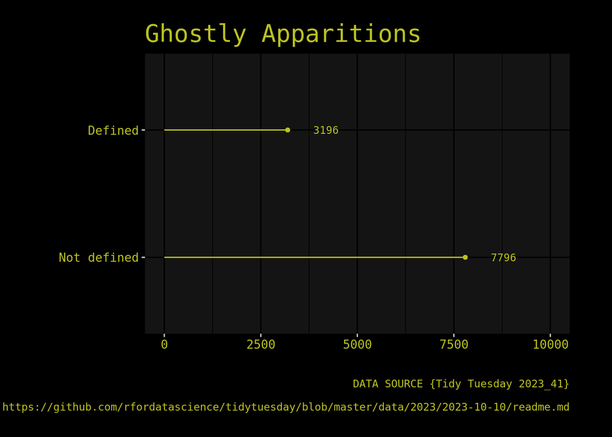

Figure 1: Status for defined and not defined ghostly apparitions

```r
haunted_places |>
  group_by(description_brief) |>
  count(description_brief) |>
  ggplot(aes(x = n, y = reorder(description_brief, desc(n)))) +
  geom_lollipop(colour = "#bac121", horizontal = TRUE) +
  geom_text(
    aes(label = n),
    color = "#bac121",
    hjust = -1,
    size = 3.0,
    family = "consolas"
  ) +
  labs(
    title = "Ghostly Apparitions",
    x = " ",
    y = " ",
    caption = "DATA SOURCE {Tidy Tuesday 2023_41}

    https://github.com/rfordatascience/tidytuesday/blob/master/data/2023/2023-10-10/readme.md"
  ) +
  dark_theme_gray() +
  theme(
    plot.margin = margin(20, 35, 20, 35),
    plot.title = element_text(
      colour = "#bac121",
      family = "consolas",
      size = 20
    ),
    axis.text.y = element_text(
      colour = "#bac121",
      family = "consolas",
      size = 10
    ),
    axis.title.x = element_text(
      colour = "#bac121",
      family = "consolas",
      size = 16
    ),
    axis.text.x = element_text(
      colour = "#bac121",
      family = "consolas",
      size = 10
    ),
    plot.caption = element_text(colour = "#bac121", family = "consolas")
  ) +
  scale_x_continuous(limits = c(0, 10000))
```

### `location_type`

```r
haunted_places <-
  haunted_places |>
  mutate(location_type = str_split(location, " ") |>  sapply(tail, 1)) |>
  mutate(
    location_type = case_when(
      location_type %in% c("School", "school", "School)") ~ "School",
      location_type %in% c("Cemetery", "cemetery") ~ "Cemetery",
      TRUE ~ location_type
    )
  )
```

[figure not shown]

```r
haunted_places |>
  group_by(location_type) |>
  count(location_type) |>
  arrange(desc(n)) |>
  filter(n >= 58) |>
  ggplot(aes(x = n, y = reorder(location_type, n))) +
  geom_lollipop(colour = "#bac121", horizontal = TRUE) +
  geom_text(
    aes(label = n),
    color = "#bac121",
    hjust = -1,
    size = 3.0,
    family = "consolas"
  ) +
  labs(
    title = "Top 25 Haunted Location Types",
    subtitle = "reported across the US",
    x = " ",
    y = " ",
    caption = "DATA SOURCE {Tidy Tuesday 2023_41}

    https://github.com/rfordatascience/tidytuesday/blob/master/data/2023/2023-10-10/readme.md"
  ) +
  dark_theme_gray() +
  theme(
    plot.margin = margin(20, 35, 20, 35),
    plot.title = element_text(
      colour = "#bac121",
      family = "consolas",
      size = 20
    ),
    plot.subtitle = element_text(
      colour = "#bac121",
      family = "consolas",
      size = 16
    ),
    axis.text.y = element_text(
      colour = "#bac121",
      family = "consolas",
      size = 10
    ),
    axis.text.x = element_text(
      colour = "#bac121",
      family = "consolas",
      size = 10
    ),
    plot.caption = element_text(colour = "#bac121", family = "consolas")
  )  +
  scale_x_continuous(limits = c(0, 1200))
```

## Analyse

Figure 3 shows ghostly apparitions by region for both defined and not-defined categories

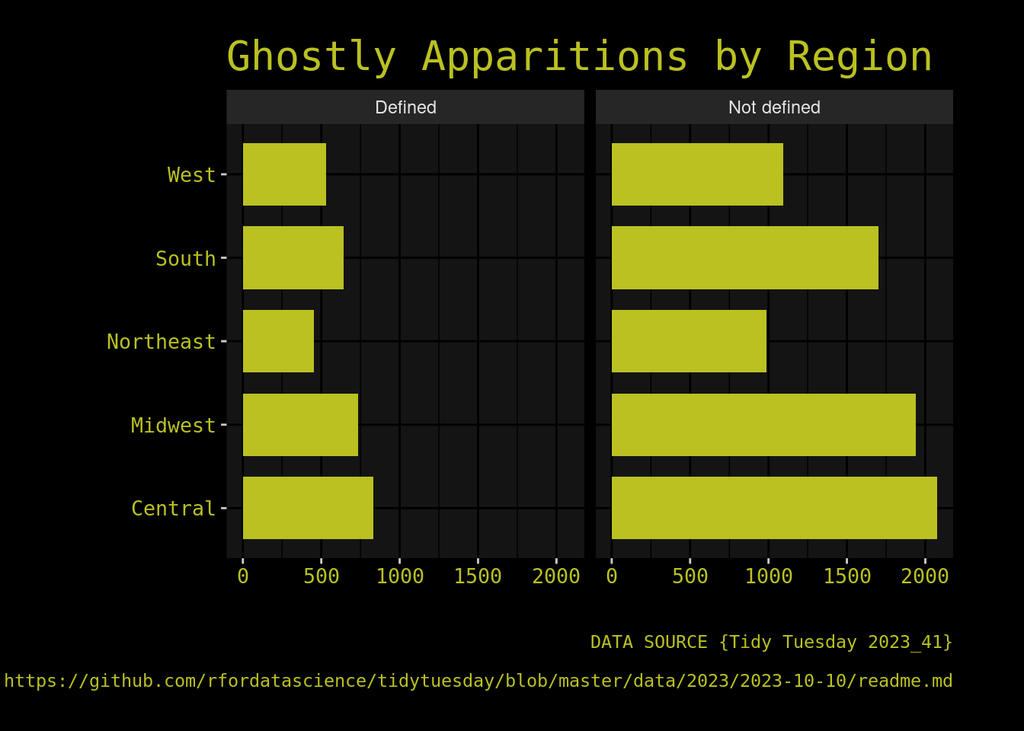

Figure 3: Ghostly apparitions by region

```r
haunted_places |>
  ggplot(aes(x = region)) +
  geom_bar(fill = "#bac121", width = 0.75) +
  labs(
    title = "Ghostly Apparitions by Region",
    x = " ",
    y = " ",
    caption = "DATA SOURCE {Tidy Tuesday 2023_41}

    https://github.com/rfordatascience/tidytuesday/blob/master/data/2023/2023-10-10/readme.md"
  ) +
  dark_theme_gray() +
  theme(
    plot.margin = margin(20, 35, 20, 35),
    plot.title = element_text(
      colour = "#bac121",
      family = "consolas",
      size = 20
    ),
    plot.subtitle = element_text(
      colour = "#bac121",
      family = "consolas",
      size = 16
    ),
    axis.title.y = element_text(
      colour = "#bac121",
      family = "consolas",
      size = 16
    ),
    axis.text.y = element_text(
      colour = "#bac121",
      family = "consolas",
      size = 10
    ),
    axis.title.x = element_text(
      colour = "#bac121",
      family = "consolas",
      size = 16
    ),
    axis.text.x = element_text(
      colour = "#bac121",
      family = "consolas",
      size = 10
    ),
    plot.caption = element_text(colour = "#bac121", family = "consolas")
  ) +
  facet_wrap( ~ description_brief) +
  coord_flip()
```

```r
table(x = haunted_places$description_brief,
      y = haunted_places$region) |>
  knitr::kable()
```

Table 2: Defined and Not defined ghostly apparitions by region

|  | Central | Midwest | Northeast | South | West |
| --- | --- | --- | --- | --- | --- |
| Defined | 834 | 737 | 453 | 641 | 531 |
| Not defined | 2074 | 1938 | 987 | 1701 | 1096 |

```r
chisq.test(x = haunted_places$description_brief,
           y = haunted_places$region)
```

```
    Pearson's Chi-squared test

data:  haunted_places$description_brief and haunted_places$region
X-squared = 20.51, df = 4, p-value = 0.000396
```

```r
cramerV(x = haunted_places$description_brief,
        y = haunted_places$region,
        bias.correct = TRUE)
```

```
Cramer V
 0.03876
```

The output of the Chi Square Test of Independence shows that the test statistic X² is 20.51, with 4 degrees of freedom and a p-value of `0.000396`, which is less than the default threshold of 0.05. In other words, there’s strong evidence for rejecting the null hypothesis that the two categorical variables are independent. Therefore, there seems to be a statistically significant relationship between the two categorical variables being studied. However, with a Cramér’s V of `0.03876`, the association is pretty low.

## Footnotes

[^1]: Such descriptions deserve a deeper dive.
[^2]: Sample calculation was done through the Raosoft calculator available at: http://www.raosoft.com/samplesize.html; margin of error was set to 5% and confidence level at 95%.